# Exercise Pattern Prediction

## Aveline Marshall and Meghan Roffler

From kaggle: https://www.kaggle.com/athniv/exercisepatternpredict

## Assignment Background

Using devices such as Jawbone Up, Nike FuelBand, and Fitbit it is now possible to collect a large amount of data about personal activity relatively inexpensively. These type of devices are part of the quantified self movement - a group of enthusiasts who take measurements about themselves regularly to improve their health, to find patterns in their behavior, or because they are tech geeks. One thing that people regularly do is quantify how much of a particular activity they do, but they rarely quantify how well they do it. In this project, your goal will be to use data from accelerometers on the belt, forearm, arm, and dumbell of 6 participants. They were asked to perform barbell lifts correctly and incorrectly in 5 different ways. More information is available from the website here: http://groupware.les.inf.puc-rio.br/har From the section on the Weight Lifting Exercise Dataset the following further information is available:

Six young health participants were asked to perform one set of 10 repetitions of the Unilateral Dumbbell Biceps Curl in five different fashions: exactly according to the specification (Class A), throwing the elbows to the front (Class B), lifting the dumbbell only halfway (Class C), lowering the dumbbell only halfway (Class D) and throwing the hips to the front (Class E).

Class A corresponds to the specified execution of the exercise, while the other 4 classes correspond to common mistakes. Participants were supervised by an experienced weight lifter to make sure the execution complied to the manner they were supposed to simulate. The exercises were performed by six male participants aged between 20-28 years, with little weight lifting experience. We made sure that all participants could easily simulate the mistakes in a safe and controlled manner by using a relatively light dumbbell (1.25kg).

Read more: http://groupware.les.inf.puc-rio.br/har#weight_lifting_exercises#ixzz4TGOJ1z64

## Model Used

The outcome variable chosen in this assignment is classe. As stated in the original WLE Dataset “Six young health participants were asked to perform one set of 10 repetitions of the Unilateral Dumbbell Biceps Curl in five different fashions: - Class A - exactly according to the specification - Class B - throwing the elbows to the front - Class C - lifting the dumbbell only halfway - Class D - lowering the dumbbell only halfway - Class E - throwing the hips to the front”

Two models will be tested using decision tree and random forest. The model with the highest accuracy will be chosen as our final model. The seed will be randomly set at 12345 for all code.

## Cross Validation

As we have a large Training data set, our cross-validation will be done by splitting our original training set into 2 subsets (randomly without replacement): TrainingTraining set (70%) and TestingTraining set (30%). The decision tree and random forest models will be developed using the TrainingTraining data set, and then tested on the TrainingTesting data. Then the most accurate model choosen will be tested on the original Testing data set.

## Out of sample error

The expected out of sample error will correspond to the quantity: 1-accuracy in the cross validation data. Accuracy is the proportion of correctly classified observations over the total sample in the TrainingTesting data set.

#### Installing Packages, Libraries and Seed

Load the previously installed packages into R:

```r
library(caret)
library(randomForest)
```

```r
library(rpart)
library(rpart.plot)
library(RColorBrewer)
set.seed(12345)
```

#### Getting and Downloading the Original Data Sets

The training data set can be found on the following URL:

```r
trainUrl <- "https://d396qusza40orc.cloudfront.net/predmachlearn/pml-training.csv"
```

The testing data set can be found on the following URL:

```r
testUrl <- "https://d396qusza40orc.cloudfront.net/predmachlearn/pml-testing.csv"
```

Save the data sets:

```r
Training <- read.csv(url(trainUrl), na.strings=c("NA","#DIV/0!",""))
Testing <- read.csv(url(testUrl), na.strings=c("NA","#DIV/0!",""))
```

#### Delete columns with all missing values

```r
Training <-Training[,colSums(is.na(Training)) == 0]
Testing <-Testing[,colSums(is.na(Testing)) == 0]
```

#### Delete variables irrelevant to the current project: user_name, raw_timestamp_part_1, raw_timestamp_part_,2 cvtd_timestamp, new_window, and num_window (columns 1 to 7).

```r
Training   <-Training[,-c(1:7)]
Testing <-Testing[,-c(1:7)]
```

#### Perform exploratory analysis:

dim(Training); dim(Testing); summary(Training); summary(Testing); str(Training); str(Testing); head(Training); head(Testing)

In order to identify a set of major variables which may directly be related to a specific class of how an exercise is being performed, selected plots have been made. However, no specific patterns could easily be identified which would have allowed to further reduce the set of predictors to the ones most specific for the different classes. The plot below is just one example of various attempts to identify a pattern between the variables and classification.

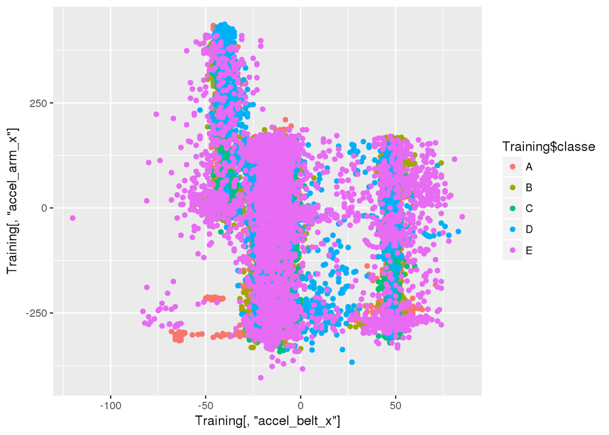

```r
qplot(x = Training[, "accel_belt_x"], y = Training[, "accel_arm_x"],
    color = Training$classe)
```

#### Partition the Training data set

Partition so that 70% of it is in the TrainingTraining data set and the remaining 30% to TestingTraining

```r
inTrainingSet <- createDataPartition(y=Training$classe, p=0.70, list=FALSE)
TrainingTraining <- Training[inTrainingSet, ]; TestingTraining <- Training[-inTrainingSet, ]
dim(TrainingTraining); dim(TestingTraining)
```

```
## [1] 13737    53
```

```
## [1] 5885   53
```

## First Prediction Model - Decision Tree

```r
FirstModel <- rpart(classe ~ ., data=TrainingTraining, method="class")
```

#### Predicting

```r
FirstPrediction <- predict(FirstModel, TestingTraining, type = "class")
```

#### Using confusion Matrix to test results:

```r
confusionMatrix(FirstPrediction, TestingTraining$classe)
```

```
## Confusion Matrix and Statistics
##
##           Reference
## Prediction    A    B    C    D    E
##          A 1498  196   69  106   25
##          B   42  669   85   86   92
##          C   43  136  739  129  131
##          D   33   85   98  553   44
##          E   58   53   35   90  790
##
## Overall Statistics
##
##                Accuracy : 0.722
##                  95% CI : (0.7104, 0.7334)
##     No Information Rate : 0.2845
##     P-Value [Acc > NIR] : < 2.2e-16
##
##                   Kappa : 0.6467
##  Mcnemar's Test P-Value : < 2.2e-16
##
## Statistics by Class:
##
##                      Class: A Class: B Class: C Class: D Class: E
## Sensitivity            0.8949   0.5874   0.7203  0.57365   0.7301
## Specificity            0.9060   0.9357   0.9097  0.94717   0.9509
## Pos Pred Value         0.7909   0.6869   0.6273  0.68020   0.7700
## Neg Pred Value         0.9559   0.9043   0.9390  0.91897   0.9399
## Prevalence             0.2845   0.1935   0.1743  0.16381   0.1839
## Detection Rate         0.2545   0.1137   0.1256  0.09397   0.1342
## Detection Prevalence   0.3218   0.1655   0.2002  0.13815   0.1743
## Balanced Accuracy      0.9004   0.7615   0.8150  0.76041   0.8405
```

## Second Prediction Model - Random Forests

```r
SecondModel <- randomForest(classe ~. , data=TrainingTraining, method="class")
```

#### Predicting:

```r
SecondPrediction <- predict(SecondModel, TestingTraining, type = "class")
```

#### Test results on TestingTraining data set:

```r
confusionMatrix(SecondPrediction, TestingTraining$classe)
```

```
## Confusion Matrix and Statistics
##
##           Reference
## Prediction    A    B    C    D    E
##          A 1673    9    0    0    0
##          B    1 1127   13    0    0
##          C    0    3 1011   14    0
##          D    0    0    2  949    5
##          E    0    0    0    1 1077
##
## Overall Statistics
##
##                Accuracy : 0.9918
##                  95% CI : (0.9892, 0.994)
##     No Information Rate : 0.2845
##     P-Value [Acc > NIR] : < 2.2e-16
##
##                   Kappa : 0.9897
##  Mcnemar's Test P-Value : NA
##
## Statistics by Class:
##
##                      Class: A Class: B Class: C Class: D Class: E
## Sensitivity            0.9994   0.9895   0.9854   0.9844   0.9954
## Specificity            0.9979   0.9971   0.9965   0.9986   0.9998
## Pos Pred Value         0.9946   0.9877   0.9835   0.9927   0.9991
## Neg Pred Value         0.9998   0.9975   0.9969   0.9970   0.9990
## Prevalence             0.2845   0.1935   0.1743   0.1638   0.1839
## Detection Rate         0.2843   0.1915   0.1718   0.1613   0.1830
## Detection Prevalence   0.2858   0.1939   0.1747   0.1624   0.1832
## Balanced Accuracy      0.9986   0.9933   0.9909   0.9915   0.9976
```

## Conclusion

Random Forest algorithm performed better than Decision Trees. Accuracy for Random Forest model was 0.99 compared to Decision Tree model with 0.72. The Random Forests model is choosen. The expected out-of-sample error is estimated at 0.008.

## Testing the better model on original Testing Set.

Here is the final outcome based on Second Prediction Model:

```r
FinalPrediction <- predict(SecondModel, Testing, type="class")
FinalPrediction
```

```
##  1  2  3  4  5  6  7  8  9 10 11 12 13 14 15 16 17 18 19 20
##  B  A  B  A  A  E  D  B  A  A  B  C  B  A  E  E  A  B  B  B
## Levels: A B C D E
```

#### As the results has shown, it is possible to provide very good prediction of weight lifting style, using accelerometers.